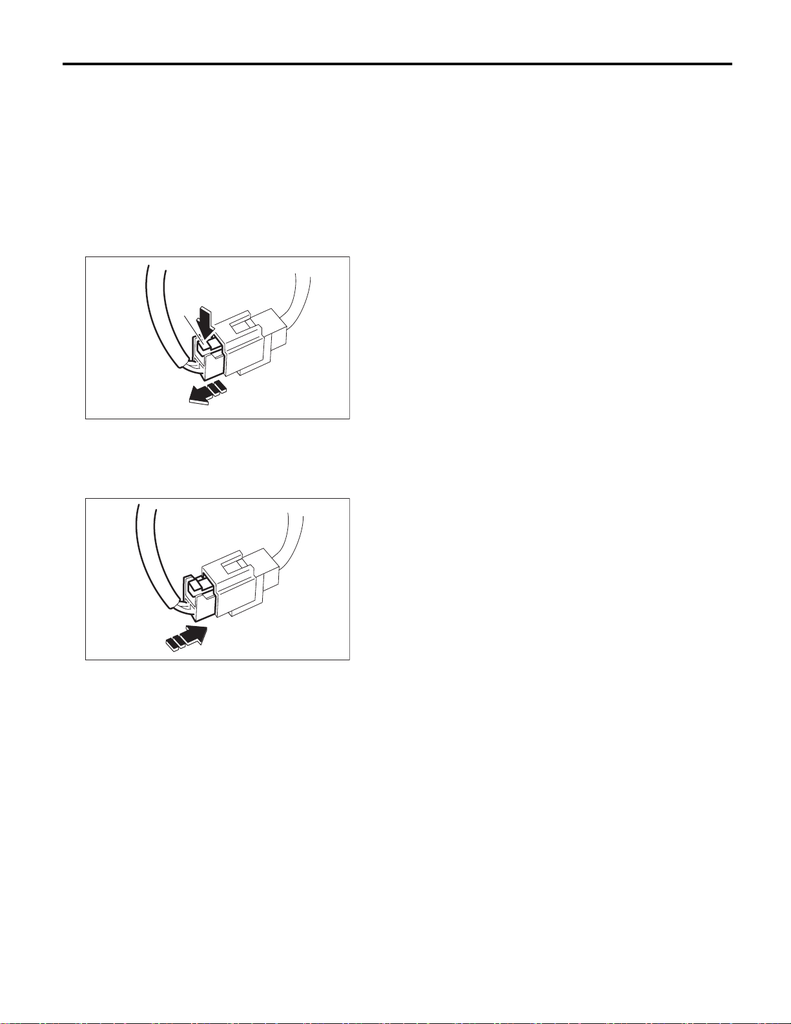

AB-17

Airbag Connector

AIRBAG SYSTEM

2. Airbag Connector

A: PROCEDURE

1. POWER SUPPLY

1) How to disconnect:

CAUTION:

When pulling the slide lock or disconnecting connector, be sure to hold the connector, not the har-

ness.

(1) Push the lock (a).

(2) While holding down the lock (a), disconnect the connector.

2) How to connect:

CAUTION:

Be sure to insert the connector in until it is locked. Then pull it gently to make sure that it is locked.

Holding the connector, push it in securely until a clicking sound is heard.

AB-03491

(1)

(2)

(a)

AB-03492

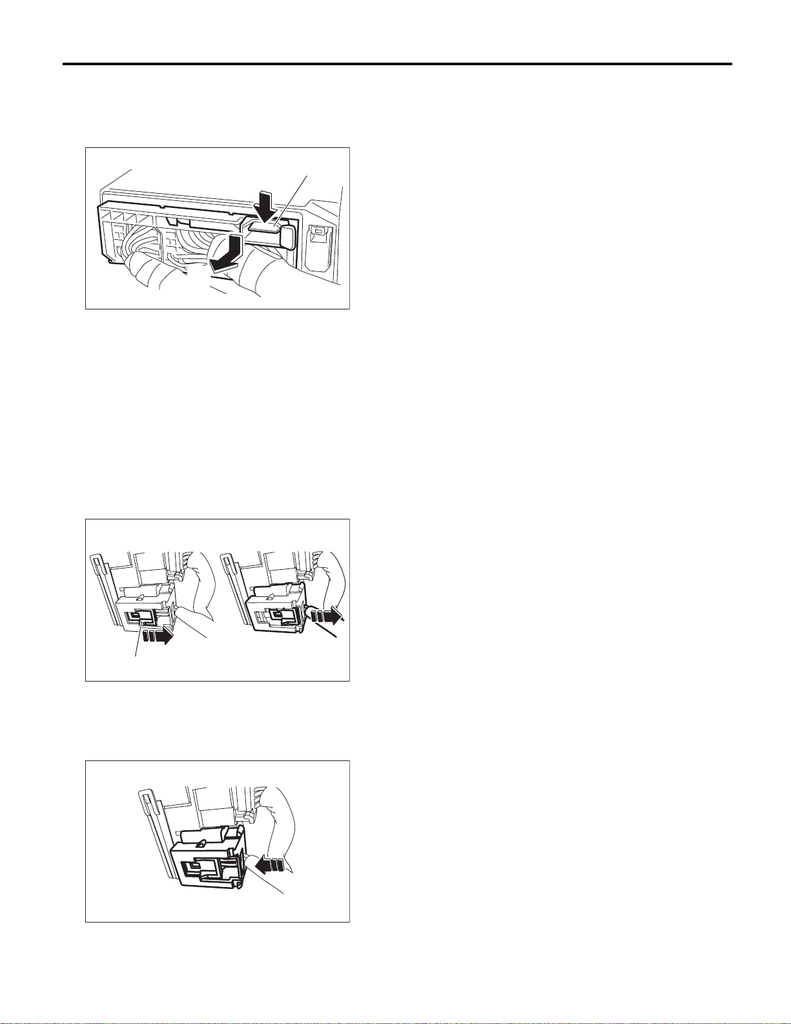

AB-18

Airbag Connector

AIRBAG SYSTEM

2. AIRBAG CONTROL MODULE

1) How to disconnect:

(1) Push the lock lever plate (a).

(2) While holding down the lock lever plate (a), pull the lever toward you.

2) How to connect:

CAUTION:

Be sure to insert the connector in until it is locked. Then pull it gently to make sure that it is locked.

Insert the connector and push the lock lever in securely.

3. DRIVER’S AIRBAG MODULE (ROLL CONNECTOR)

1) How to disconnect:

CAUTION:

When pulling the slide lock or disconnecting connector, be sure to hold the connector, not the har-

ness.

(1) Pull the slide lock (a) in the direction of arrow.

(2) With the slide lock pulled, disconnect the connector.

2) How to connect:

CAUTION:

Be sure to insert the connector in until it is locked. Then pull it gently to make sure that it is locked.

Holding the connector, push it in securely until a clicking sound is heard.

AB-03493

(a)

(1)

(2)

AB-03494

(1)

(2)

(a)

AB-03495

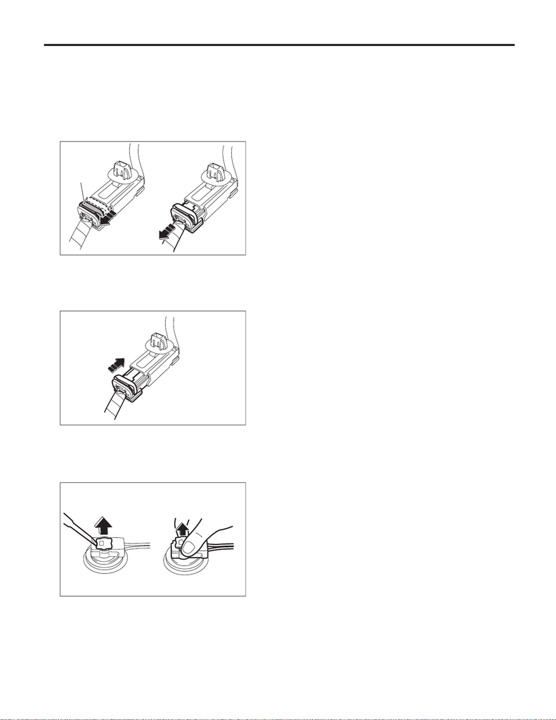

AB-19

Airbag Connector

AIRBAG SYSTEM

4. PASSENGER’S AIRBAG MODULE

1) How to disconnect:

CAUTION:

When pulling the slide lock or disconnecting connector, be sure to hold the connector, not the har-

ness.

(1) Pull the slide lock (a) in the direction of arrow.

(2) With the slide lock pulled, disconnect the connector.

2) How to connect:

CAUTION:

Be sure to insert the connector in until it is locked. Then pull it gently to make sure that it is locked.

Holding the connector, push it in securely until a clicking sound is heard.

5. DRIVER’S AIRBAG MODULE, CURTAIN AIRBAG MODULE & PRETENSIONER

1) How to disconnect:

(1) Using a flat tip screwdriver, pry the push lock upward to unlock.

(2) Pull the connector to disconnect from the airbag module assembly or the retractor assembly.

AB-03496

(1)

(a)

(2)

AB-03497

AB-03498

(1)

(2)

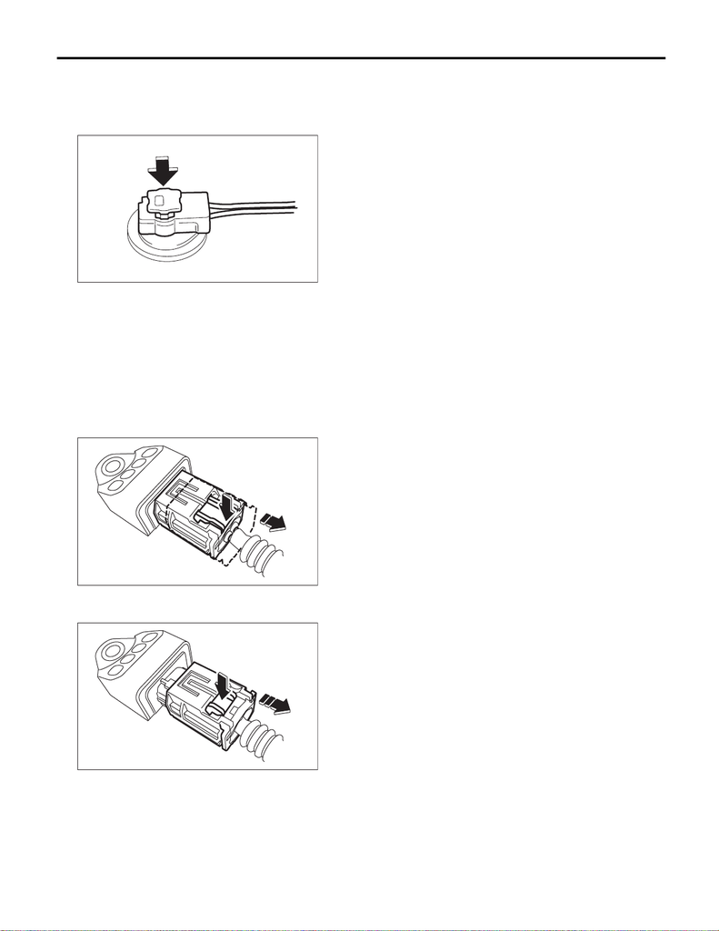

AB-20

Airbag Connector

AIRBAG SYSTEM

2) How to connect:

CAUTION:

• Be sure to insert the connector in until it is locked.

• Press in the push lock securely. Then pull it gently to make sure that it is locked.

Connect the connector in the reverse order of disconnecting. At this time, be sure to insert until a clicking

sound is heard.

6. FRONT SUB SENSOR

1) How to disconnect:

CAUTION:

When pulling the slide lock or disconnecting connector, be sure to hold the connector, not the har-

ness.

(1) Push the lock arm.

(2) Holding outer part, pull it one step in the direction of arrow.

(3) Push the lock arm again.

(4) Holding outer part, pull it in the direction of arrow to disconnect the connector.

AB-03499

AB-02032

(2)

(1)

AB-02033

(3)

(4)

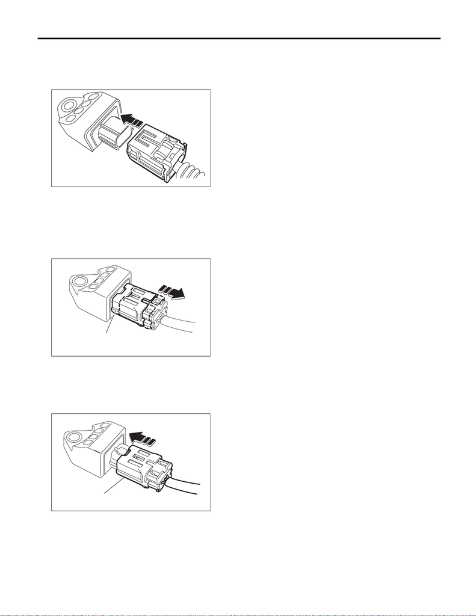

AB-21

Airbag Connector

AIRBAG SYSTEM

2) How to connect:

CAUTION:

Be sure to insert the connector in until it is locked. Then pull it gently to make sure that it is locked.

Holding the connector, push it in securely until a clicking sound is heard.

7. FRONT DOOR IMPACT SENSOR AND SATELLITE SAFING SENSOR

1) How to disconnect:

CAUTION:

When pulling the slide lock or disconnecting connector, be sure to hold the connector, not the har-

ness.

Holding outer part (a), pull it in the direction of arrow.

2) How to connect:

CAUTION:

• The outer part (a) returns to the original position. Therefore do not touch the outer part.

• Be sure to insert the connector in until it is locked. Then pull it gently to make sure that it is locked.

Holding the connector, push it in securely until a clicking sound is heard.

AB-02034

AB-03503

(a)

AB-03504

(a)

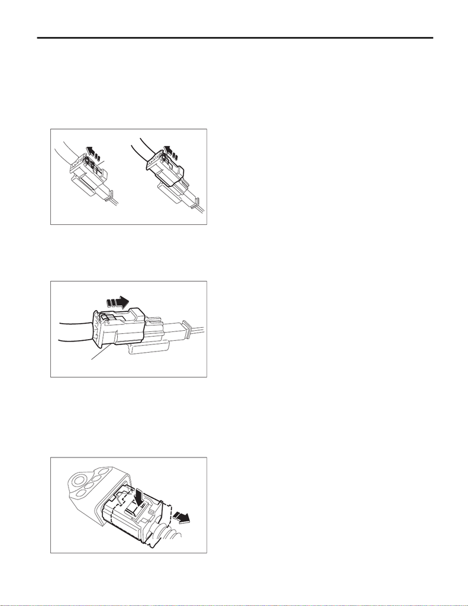

AB-22

Airbag Connector

AIRBAG SYSTEM

8. FRONT DOOR IMPACT SENSOR (BETWEEN AIRBAG REAR HARNESS AND DOOR HAR-

NESS)

1) How to disconnect:

CAUTION:

When pulling the slide lock or disconnecting connector, be sure to hold the connector, not the har-

ness.

(1) Pull the slide lock (a) in the direction of arrow.

(2) With the slide lock pulled, disconnect the connector.

2) How to connect:

CAUTION:

• The outer part (a) returns to the original position. Therefore do not touch the outer part.

• Be sure to insert the connector in until it is locked. Then pull it gently to make sure that it is locked.

Holding the connector, push it in securely until a clicking sound is heard.

9. SIDE AIRBAG SENSOR AND CURTAIN AIRBAG SENSOR

1) How to disconnect:

CAUTION:

When pulling the slide lock or disconnecting connector, be sure to hold the connector, not the har-

ness.

(1) Push the lock arm.

(2) Holding outer part, pull it one step in the direction of arrow.

(3) Push the lock arm again.

AB-03505

(1)

(a)

(2)

AB-03506

(a)

AB-02605

(2)

(1)

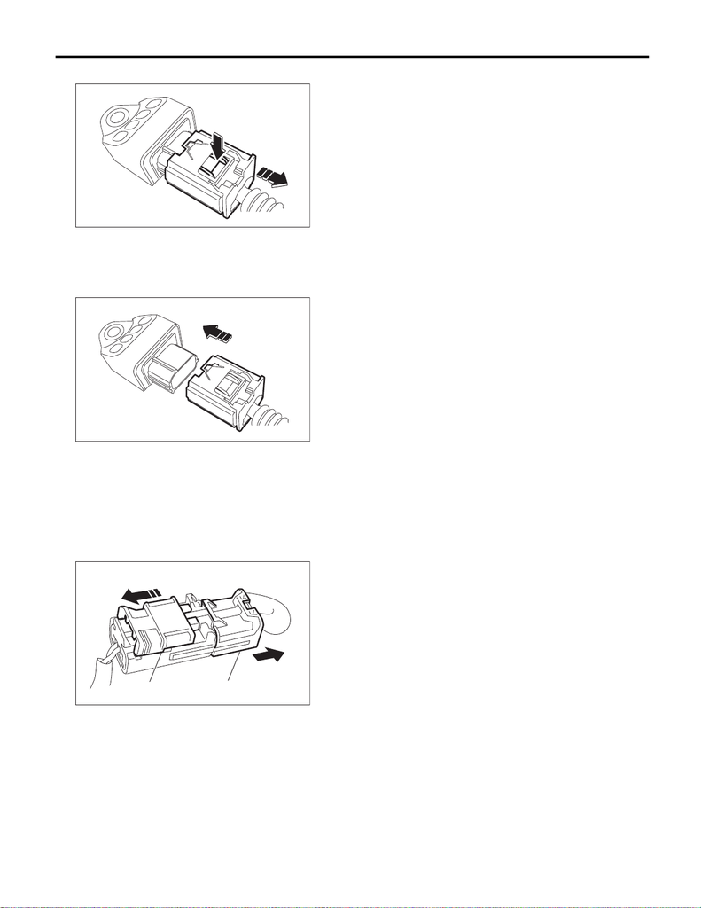

AB-23

Airbag Connector

AIRBAG SYSTEM

(4) Holding outer part, pull it in the direction of arrow to disconnect the connector.

2) How to connect:

CAUTION:

Be sure to insert the connector in until it is locked. Then pull it gently to make sure that it is locked.

Holding the connector, push it in securely until a clicking sound is heard.

10.SIDE AIRBAG MODULE

1) How to disconnect:

CAUTION:

When pulling the slide lock or disconnecting connector, be sure to hold the connector, not the har-

ness.

(1) Move the slide lock (a) in the direction of arrow and hold it.

(2) While holding the slide lock (a), pull the connector (b) in the direction of arrow.

AB-02606

(3)

(4)

AB-02607

AB-03510

(a)

(b)

(1)

(2)

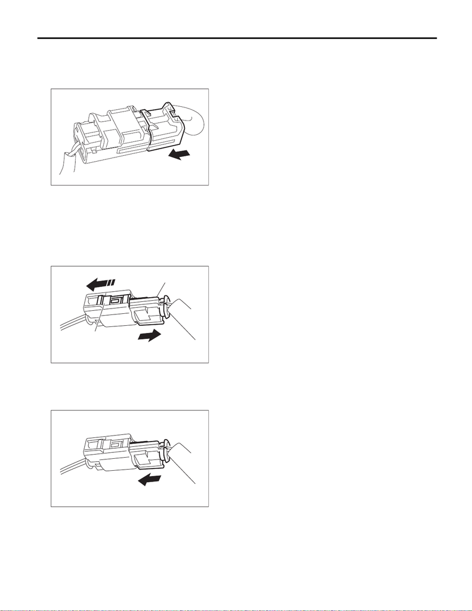

AB-24

Airbag Connector

AIRBAG SYSTEM

2) How to connect:

CAUTION:

Be sure to insert the connector in until it is locked. Then pull it gently to make sure that it is locked.

Holding the connector, push it in securely until a clicking sound is heard.

11.BUCKLE SWITCH RH

1) How to disconnect:

CAUTION:

When pulling the slide lock or disconnecting connector, be sure to hold the connector, not the har-

ness.

(1) Move the slide lock (A) in the direction of arrow and hold it.

(2) While holding the slide lock (A), pull the connector (B) in the direction of arrow.

2) How to connect:

CAUTION:

Be sure to insert the connector in until it is locked. Then pull it gently to make sure that it is locked.

Holding the connector, push it in securely until a clicking sound is heard.

12.OCCUPANT DETECTION SYSTEM (BETWEEN AIRBAG REAR HARNESS AND SEAT HAR-

NESS)

Refer to “OCCUPANT DETECTION SYSTEM” section. <Ref. to OD(diag)-9, OCCUPANT DETECTION

SYSTEM (BETWEEN AIRBAG REAR HARNESS AND SEAT HARNESS), PROCEDURE, Airbag Connec-

tor.>

AB-03511

AB-01899

(A)

(B)

AB-01900

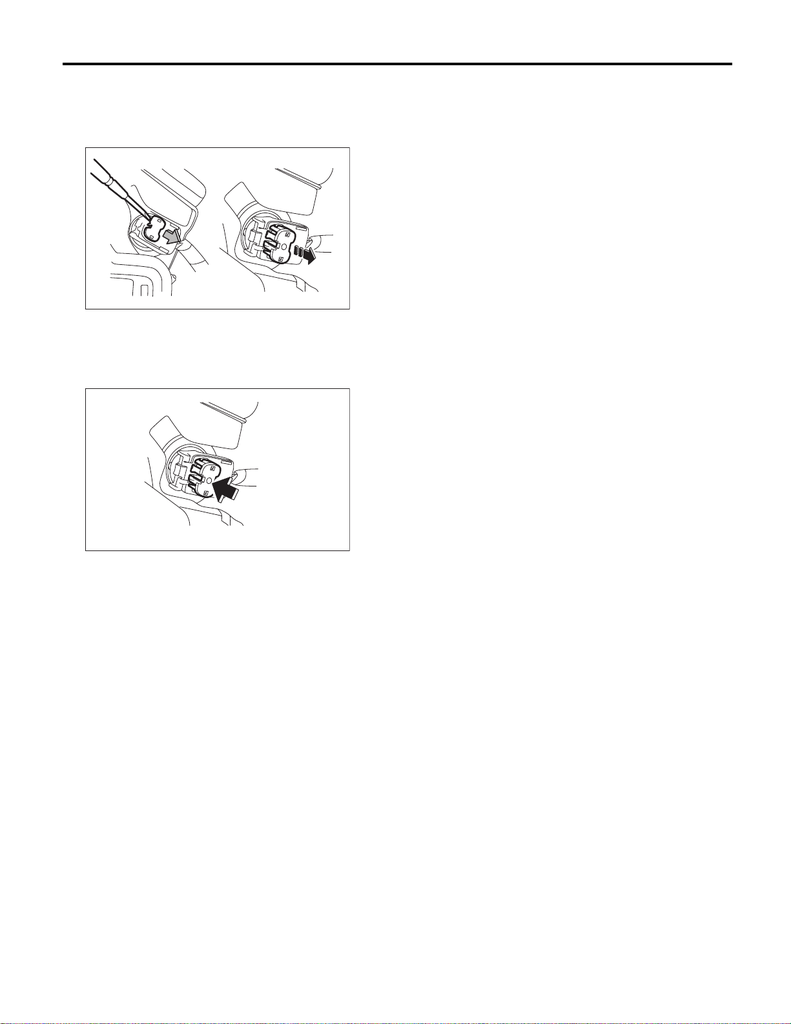

AB-25

Airbag Connector

AIRBAG SYSTEM

13.KNEE AIRBAG MODULE

1) How to disconnect:

(1) Using a flat tip screwdriver, pry the push lock upward to unlock.

(2) Pull the connector to disconnect from the airbag module assembly.

2) How to connect:

CAUTION:

• Be sure to insert the connector in until it is locked.

• Press in the push lock securely. Then pull it gently to make sure that it is locked.

Connect the connector in the reverse order of disconnecting. At this time, be sure to insert until a clicking

sound is heard.

AB-03512

(1)

(2)

AB-03513